# Post-Hoc Analysis

Matthew Loder

8/9/2019

```r
library(ggplot2)
library(dplyr)
library(tidyr)
library(data.table)
library(gridExtra)
library(DescTools)
library(splines)
library(stringr)
source("helpers.R")
theme_set(theme_bw())
colscale = scale_color_manual(values=c("#7CB637", "#666666", "#4381C1"))
colscale_fill = scale_fill_manual(values=c("#7CB637", "#666666", "#4381C1"))
remove_quotes = function(d) {

}
exclude_random = function(d) {
  d_overall_means = d %>%
  group_by(modal, workerid) %>%
  summarise(rating_m_overall = mean(rating))
  d_indiv_means =  d %>%
    group_by(modal,percent_window, workerid) %>%
    summarise(rating_m = mean(rating))

  d_indiv_merged = merge(d_indiv_means, d_overall_means, by=c("workerid", "modal"))

  cors = d_indiv_merged %>%
    group_by(workerid) %>%
    summarise(corr = cor(rating_m, rating_m_overall))

  exclude = cors %>%
    filter(corr > 0.75) %>%
    .$workerid

  print(paste("Excluded", length(exclude), "participants based on random responses."))

  d = d %>% filter(!(workerid %in% exclude))
}
format_data = function(d) {
  drops <- c("modal1","rating1")
  d2 = d[ , !(names(d) %in% drops)]
  setnames(d2, old=c("rating2","modal2"), new=c("rating", "modal"))

  drops <- c("modal2","rating2")
  d3 = d[ , !(names(d) %in% drops)]
  setnames(d3, old=c("rating1","modal1"), new=c("rating", "modal"))

  drops <- c("modal2", "rating2", "modal1", "rating1")
  d4 = d[ , !(names(d) %in% drops)]
  d4$rating = d4$rating_other
  d4$modal = "other"

  d = rbind(d2, d3, d4)

  d$modal = gsub('"', '', d$modal)
  d$modal = factor(d$modal, levels = c("might", "probably", "other"), ordered = T)

  d$percent_window_f = factor(d$percent_window)

  d_aisle = d %>% filter(.,grepl("aisle", type))
  d_window = d %>% filter(.,grepl("window", type))

  d_aisle_reverse = d_aisle
  d_aisle_reverse$percent_window = 100-d_aisle$percent_window

  d_comparison = rbind(d_window, d_aisle_reverse)
  d_comparison$percent_window_f = factor(d_comparison$percent_window)

  return(d_comparison)
}
```

## Visualizing AUC differences by participant

The first thing that I want to look at is if there is categorical variation in the adaptation effects for the participants in the pessimist condition - that is, I want to isolate whether or not there are some speakers who adapt and some who don’t, or if there are some speakers who become more uncertain in their ratings than others.

### Load Data

```
[1] "Excluded 34 participants based on random responses."
```

### AUC Computation

[output not shown]

To look at the first part of this, it makes sense to start by comparing the AUC differences for all of the participants in the Pessimist condition. In plotting this data, we might see a sort of split between participants, or we may see an even spread. By looking at the spread of the distribition, we get a clearer picture of what’s going on.

### AUC plots

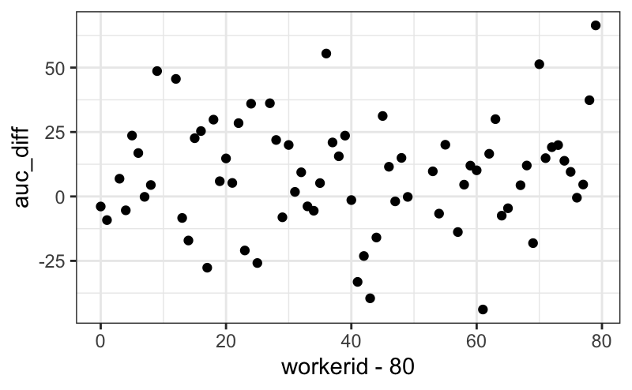

```r
aucs.pessimist.plot1 = ggplot(data = aucs.pessimist) +
  geom_point(mapping = aes(x = workerid - 80, y = auc_diff))
aucs.cautious.plot1 = ggplot(data = aucs.cautious) +
  geom_point(mapping = aes(x = workerid - 160, y = auc_diff))
aucs.pessimist.plot1
```

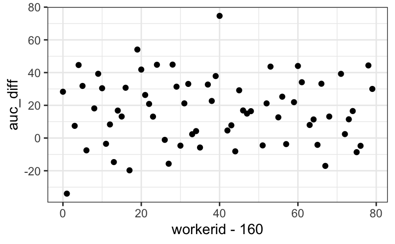

```r
aucs.cautious.plot1
```

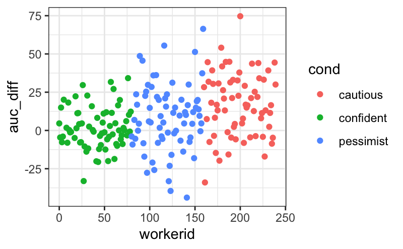

```r
aucs.all.plot1 = ggplot(data = aucs.all) +
  geom_point(mapping = aes(x = workerid, y = auc_diff, col=cond))
aucs.all.plot1
```

Presumably, in the above plot, those participants with higher AUC ratings have adapted more than those with lower AUC ratings. We can compare this with the values for the cautious and confident speakers as well, and look at the spread of the data below.

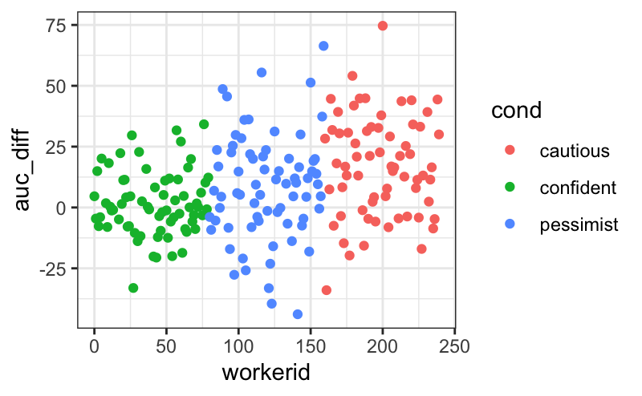

```r
aucs.all.plot2 = ggplot(data = aucs.all) +
  geom_point(mapping = aes(x = workerid, y = auc_diff, col=cond))
aucs.all.plot2
```

Finally, I’ll look at the distributions in a histogram plot, with bins of size 5

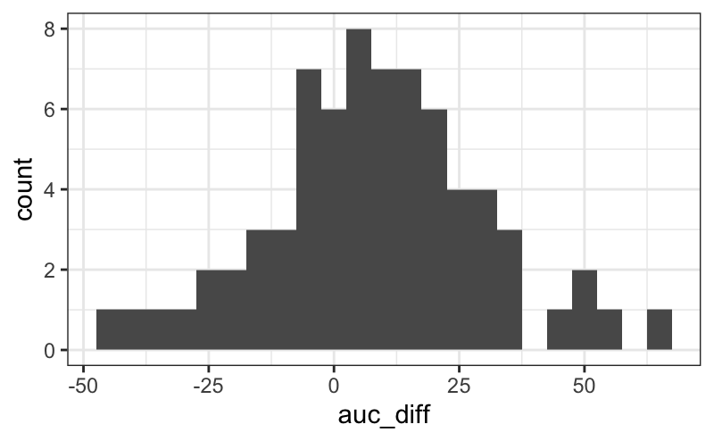

```r
aucs.pessimist.plot2 = ggplot(data = aucs.pessimist, mapping = aes(x = auc_diff)) +
  geom_histogram(binwidth = 5)
aucs.cautious.plot2 = ggplot(data = aucs.cautious, mapping = aes(x = auc_diff)) +
  geom_histogram(binwidth = 5)
aucs.confident.plot2 = ggplot(data = aucs.confident, mapping = aes(x = auc_diff)) +
  geom_histogram(binwidth = 5)
aucs.all.plot3 = ggplot(data = aucs.all, mapping = aes(x = auc_diff, fill = cond)) +
  geom_histogram(binwidth = 5, position = "identity", alpha = 2/5)
aucs.pessimist.plot2
```

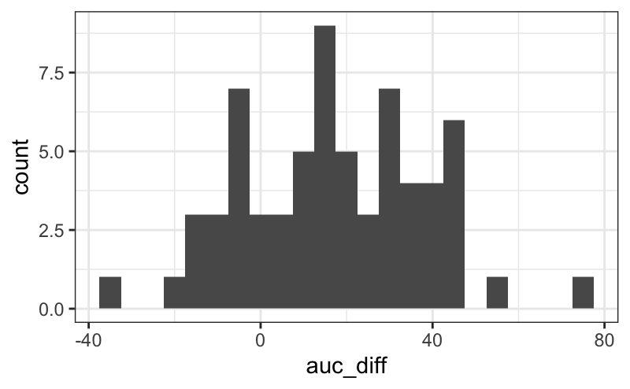

```r
aucs.cautious.plot2
```

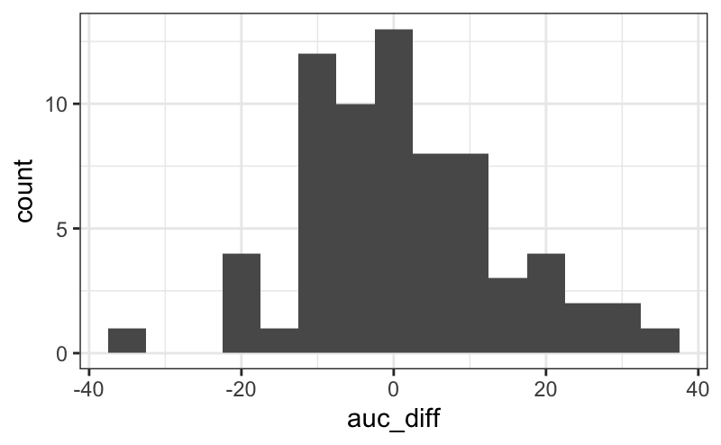

```r
aucs.confident.plot2
```

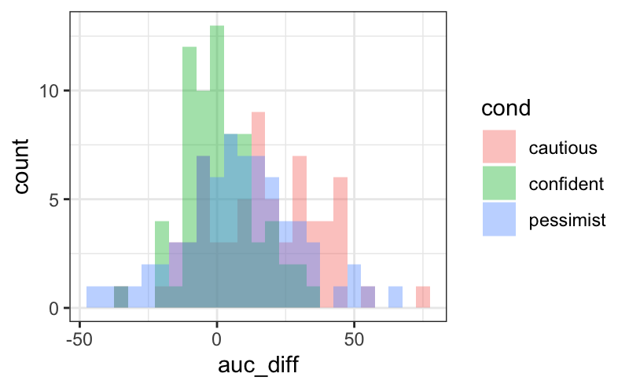

```r
aucs.all.plot3
```

## Visualizing differences in variation/certain by participant

I’ve had an idea, in addition to looking at the overall differences in the area in the curve across participants, it might also make sense to look at the absolute value of the difference in the ratings of participants for individual items. This measure, combined with the AUC measure might give us a clearer picture of what’s going on.

So let’s look at the average squared differance in ratings for might and probably by participant and condition, and by item and condition

### Compute differences in ratings per participant

```r
# We want to start by finding the difference in might and probably ratings for each item
d.might = d %>% filter(modal == "might")
d.probably = d %>% filter(modal == "probably")
d.rating_diff = data.frame("might_rating" = d.might$rating,
                           "probably_rating" = d.probably$rating,
                           "rating_diff" = (d.might$rating - d.probably$rating) ^ 2,
                           "workerid" = d.might$workerid,
                           "probability" = d.might$percent_window,
                           "condition" = d.might$Answer.condition
                           )
# Now we'll look at the average differences by speaker
avg_diff_by_speaker = d.rating_diff %>%
  group_by(workerid, condition) %>%
  summarise(rating_diff_m = mean(rating_diff))
# and then by probability
avg_diff_by_prob = d.rating_diff %>%
  group_by(probability, condition) %>%
  summarise(rating_diff_m = mean(rating_diff))
# and then the average across conditions, by speaker, and by item
avg_diff_by_cond = d.rating_diff %>%
  group_by(condition) %>%
  summarise(rating_diff_m = mean(rating_diff))
```

### Visualize differences

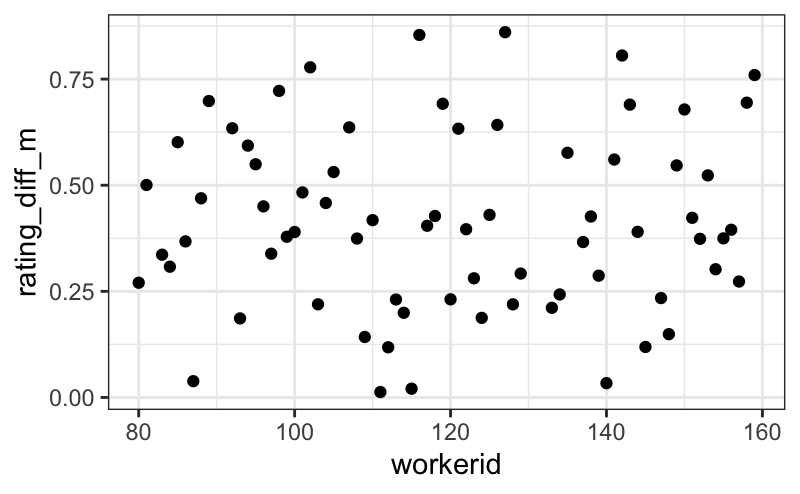

```r
avg_diff.pessimist1 = avg_diff_by_speaker %>% filter(condition == "pessimist")
avg_diff.pessimist2 = avg_diff_by_prob %>% filter(condition == "pessimist")
pessimist.rating.plot1 = ggplot(data = avg_diff.pessimist1) +
  geom_point(mapping = aes(x = workerid, y = rating_diff_m))
worker_rating.plot1 = ggplot(data = avg_diff_by_speaker) +
  geom_point(mapping = aes(x = workerid,
                           y = rating_diff_m,
                           col = condition))

prob.rating.plot1 = ggplot(data = avg_diff_by_prob) +
  geom_bar(stat = "identity",
           mapping = aes(x = probability, y = rating_diff_m, fill = condition),
           position = "dodge")
pessimist.rating.plot1
```

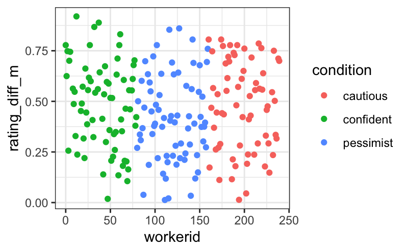

```r
worker_rating.plot1
```

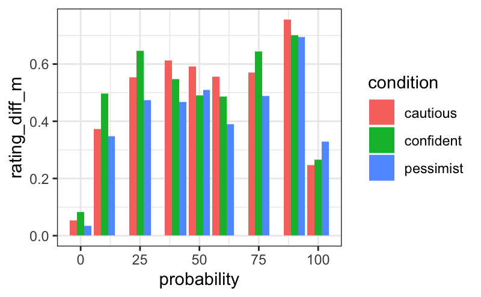

```r
prob.rating.plot1
```

Finally, consider comparing this difference in the ratings with the individual participants’ AUCs

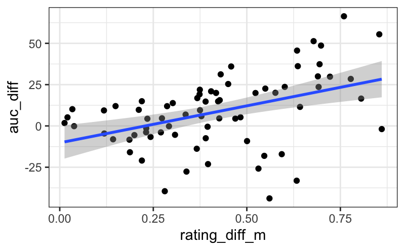

```r
aucs_and_diffs = data.frame("workerid" = aucs.all$workerid,
                            "rating_diff_m" = avg_diff_by_speaker$rating_diff_m,
                            "auc_diff" = aucs.all$auc_diff,
                            "condition" = avg_diff_by_speaker$condition)
aucs_and_diffs.pessimist = aucs_and_diffs %>% filter(condition == "pessimist")
aucs_and_diffs.plot1 = ggplot(data = aucs_and_diffs.pessimist) +
  geom_point(mapping = aes(x = rating_diff_m, y = auc_diff)) +
  geom_smooth(method = 'lm',
              mapping = aes(x = rating_diff_m, y = auc_diff))
aucs_and_diffs.plot1
```

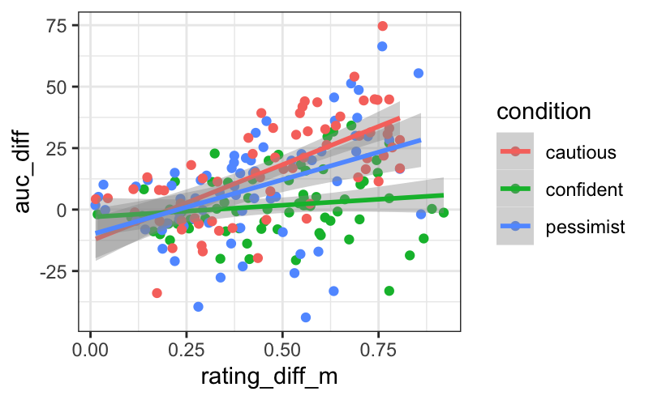

```r
aucs_and_diffs.plot2 = ggplot(data = aucs_and_diffs) +
  geom_point(mapping = aes(x = rating_diff_m,
                           y = auc_diff,
                           col = condition)) +
  geom_smooth(method='lm',
              mapping = aes(x = rating_diff_m,
                           y = auc_diff,
                           col = condition))
aucs_and_diffs.plot2
```